# Part II - US Accidents

## by Chidinma Okoro

## Investigation Overview

The aim of this investigation is to understand the distribution of accidents in US states in the past 6 years and to know the environmental factors that affect severity of accidents.

## Dataset Overview

The dataset in this project is retrieved from Kaggle at https://www.kaggle.com/datasets/sobhanmoosavi/us-accidents that contains car accidents countrywide, covering 49 states within the USA. This data has been collected from February 2016 to December 2021

## Visualization #1: Which state have the highest number of accidents?

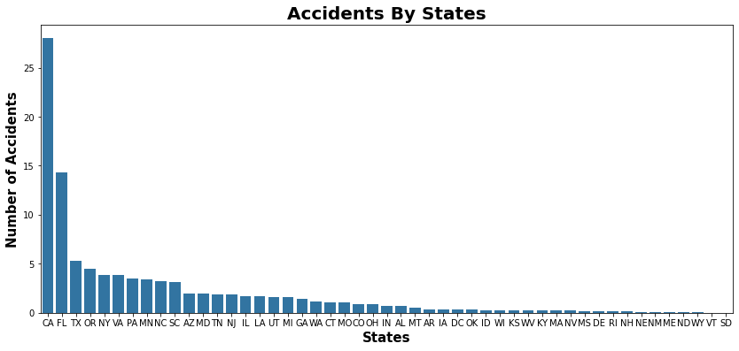

- In US, California is the state with highest no. of road accidents in past 6 years.
- Over 25% of the total accident records of past 6 years in US is only from California.
- Florida is the 2nd highest (14% cases) state for no. road accidents in US.

## Visualization #2: What has been the trend of yearly car accidents?

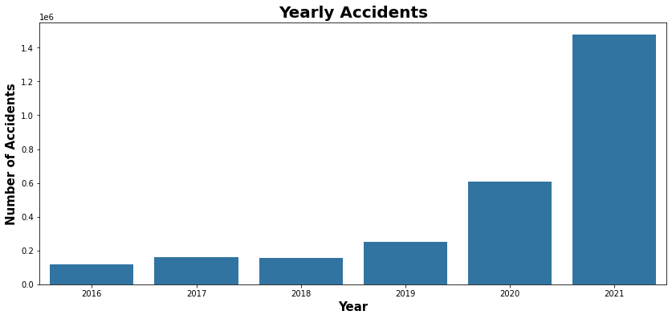

#### Next, lets get the distribution of accidents during the week.

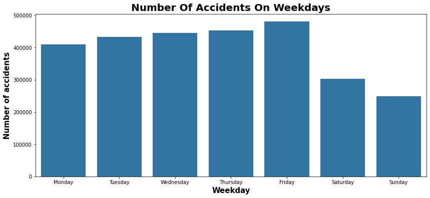

- Accidents are more common during the weekday with friday being the highest than weekends.

## Visualization #3: Distribution of Temperature

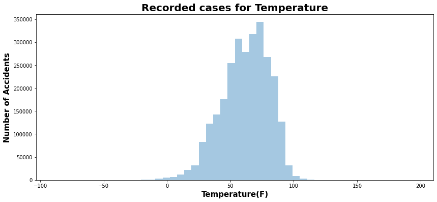

- The temperature is follows a normal distribution.
- More car accidents happened at the temperature around 50-80 F degree.

### Now lets look at the relationship between temperature and severity;

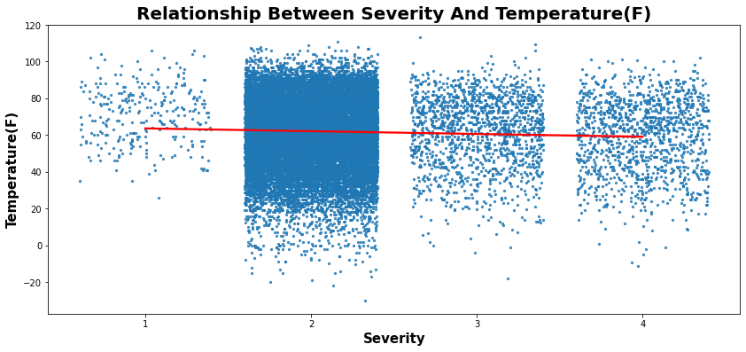

This scatter plot showed that temperature does not have much impact on the severity of the accident. However, extreme weather temperature, usually only causes accidents that have a severity score of 2.